# PEC 2: análisis de datos de ultrasecuenciación

Jone Renteria Aguirregabiria

29/5/2020

**Para la reproducción de este proyecto en su totalidad, se facilita el siguiente link al repositorio de GitHub personal del autor. De este modo, el trabajo podrá ser clonado en cualquier ordenador. [Acceso directo a: jonerenteria_RNA_Seq-analysis—PEC2](https://github.com/jonerenteria/RNA_Seq-ultrasequencing). La clonación es posible utilizando GitBash, GitGUI o un proyecto en R.**

# 1 Abstract

Este estudio analiza los datos de expresión obtenidos en el repositorio GTEx1. Los datos recogen información perteneciente a un análisis de tiroides donde se comparan tres tipos de infiltración medidos en un total de 292 muestras divididas en tres grupos: NIT, *Not infiltrated tissues*, SFI, *Small focal infiltrates* y ELI, *Extensive lymphoid infiltrated*. El proceso se lleva a cabo mediante secuenciación ARN (conocido comúnmente como *RNA-Seq*), que es una tecnología que utiliza la *next-generation sequencing (NGS)* para analizar la presencia y la cantidad de ARN en una muestra biológica en un momento determinado, analizando el cambio celular contínuo. En este estudio, comenzando desde la generación de una matriz a partir de los archivos *count* y *targets* proporcionados, se obtiene la significación biológica de los genes más significativos en los tres grupos mencionados previamente.

# 2 Objetivos

El objetivo principal de esta práctica es llevar a cabo el análisis de secuenciación (RNA-Seq) de los datos proporcionados. Como primer objetivo está llevar a cabo la selección adecuada de los datos, mediante los paquetes *dplyr* y *tydr* por ejemplo, para trabajar con diez muestras de cada grupo. El segundo objetivo será realizar paso a paso el proceso en R para obtener los genes diferencialmente expresados de las 30 muestras escogidas aleatoriamente para analizar su significación biológica de dos en dos entre los tres grupos propuestos (en total tres comparaciones) para finalmente conseguir el objetivo principal. Otro objetivo de esta práctica que no tiene relación con la ultrasecuenciación en si, es la realización de un documento dinámico que recoja toda la información sobre el proceso llevado a cabo, mostrando los resultados obtenidos en cada paso. Además, a este último objetivo se le suma el uso de GitHub, donde se ha generado un repositorio para facilitar la reproducción del trabajo.

# 3 Materiales y Métodos

A continuación se describe el tipo de experimento, los datos y los métodos utilizados para llevar a cabo el análisis de ultrasecuenciación.

## 3.1 Datos, tipo de experimento y diseño experimental

Para llevar a cabo el análisis de datos de ultrasecuenciación, primeramente se han cargado los datos de las muestras del estudio obtenido en el repositorio GTEx. En concreto, se han seleccionado los datos de expresión RNA-seq pertenecientes a un análisis de tiroides en donde se comparan tres tipos de infiltración medidos en 292 muestras separadas en tres grupos. Estos grupos son los siguientes:

- *Not infiltrated tissues* (NIT): 236 muestras
- *Small focal infiltrates* (SFI): 42 muestras
- *Extensive lymphoid infiltrates* (ELI): 14 muestras

## 3.2 Métodos y herramientas utilizadas en el análisis

**Workflow**

A continuación se describen los pasos llevados a cabo para la resolución del análisis de ultrasecuenciación en el Software R.

### 3.2.1 Definición de los datos

El objetivo de la primera parte del análisis ha sido la selección de 10 muestras aleatorias de cada uno de los tres grupos de análisis descritos previamente. Para ello, ha sido necesario cargar ambos archivos (*targets*) y (*counts*) en R, utilizando la función *read.csv*, dado que ambos se encuentran en ese formato en el repositorio de Github.

Una vez tenemos los dos archivos cargados, utilizando el paquete *dplyr* se ha llevado a cabo la selección aleatoria de 10 muestras de cada uno de los tres grupos (NIT, SFI y ELI). Para ello, mediante la función *split* se ha separado el *dataframe* targets según los grupos que se describen en la columna *Group* del mismo *dataset*. Por lo tanto, hemos obtenido una lista separada en los tres grupos que se definen en la columna *Group*. Para la selección aleatoria de la muestra, se ha generado una función, denominada en este caso *gen*. El objetivo de la función ha sido generar un *dataframe* que coja 10 filas de forma aleatoria de un conjunto de datos que se le introduzca a la función. Además, para asegurar la repetitividad de los datos, se ha especificado la semilla *123*. Una vez definida la función, se ha procedido a la *llamada* de la misma. Debemos recordar que nuestro objetivo es obtener 10 muestras **de cada grupo**, es decir, en total **30** muestras. Para ello, con la función *lapply* hemos aplicado la función generada *gen* sobre el listado formado previamente con la función *split*. Sin embargo, para poder trabajar adecuadamente en los siguientes apartados, necesitamos tener los datos en un *dataframe* y unir la división del listado. Lo conseguiremos utilizando la función *bind_rows* sobre el listado.

Por lo tanto, el *dataframe* que hemos generado (denominado *fin*) tiene 30 observaciones y 9 variables. Sin embargo, el siguiente paso consiste en seleccionar las columnas escogidas en el archivo *counts.csv* según las 30 filas que hemos seleccionado aleatoriamente. El *dataframe* generado se ha guardado como un `csv` en la carpeta de resultados.

Para llevar a cabo este paso, lo primero que se ha hecho ha sido modificar el nombre de la columna *Sample_Name*, puesto que son diferentes a los que hay en el archivo *counts*. La diferencia entre los nombres es que en el *dataset counts*, las diferentes secciones están separadas con puntos, y en *targets* con guiones. Por lo tanto, con la función *gsub* hemos modificado los nombres en el *dataframe* generado previamente, y hemos puesto todos los nombres con puntos.

Para seleccionar las columnas coincidentes del *dataframe* que contiene las 30 observaciones (10 de cada tipo), con las del *dataframe* *counts*, hemos utilizado los paquetes *tidyr* y *dplyr*. Mediante los *pipes* *(%>%)*, hemos utilizado las funciones *gather*, *left_join* y *filter*:

- *Gather*: se han generado dos columnas con todos los valores de las columnas originales de *counts* (excluyendo la columna X que tiene los nombres *ENSGO*). Por lo tanto, se comprime toda la información del *dataframe* original a tres únicas columnas.
- *Left_join*: tras aplicar *gather*, con esta función lo que se ha hecho ha sido *sumarle* las columnas del *dataframe* generado para la selección de las 10 muestras. Sin embargo, ahora hay muchas más combinaciones, por lo tanto, la mayoría de casillas serán valores NA. Para solucionar esto, aplicamos la siguiente función.
- *Filter*: la última función *filter* junto con *complete.cases(.)* lo que hace es quedarse únicamente con las entradas que no tienen valores NA.

Debemos recordar que el *dataset* original de *counts.csv* contiene 56202 filas. Por lo tanto, el *dataset* final que hemos denominado *counts.long* tiene, esas filas multiplicadas por las 30 variables, es decir, 1686060. Tendrá 11 columnas.

Para llevar a cabo el análisis posterior de una forma más simple, del *dataset* *counts.long* que recoge todas las combinaciones posibles entre las 10 muestras, seleccionaremos únicamente tres: *X* (define las entradas ENSG0), *value* (el valor) y las muestras *SRA*. Para ello utilizaremos la función *select*.

Además, será necesario transformar del conjunto de datos de la siguiente manera: las entradas ENSEMBL (ENSG0) serán las filas y cada RNA_Sample (librería secuenciada de RNA) serán las columnas. Entre cada fila y columna, tendremos el valor, que se recoge en la columna *value*, y que en definitiva muestran los valores asignados a cada gen de cada librería . Finalmente, transformaremos el conjunto de datos en una matriz para poder trabajar con ella más adelante. En inglés se denomina *count matrix*.

Por lo tanto, nuestra *count matrix* final tiene 56202 filas (entradas ENSEMBL) y 30 columnas, correspondientes a las librerías *RNA_Sample* que hemos seleccionado aleatoriamente al principio, cada una correspondiente a un grupo: ELI, NIT o SFI.

Es importante que las columnas de la matriz *count* y las filas del data frame que contiene la información (en nuestro caso *fin*) estén en el mismo orden y por ello conviene comprobarlo. Se observa mediante la función *all(as.vector(fin$SRA_Sample) == colnames(counts.long3))* que esta igualdad es verdadera (*true*). El resultado se ha guardado en un archivo `csv` en la carpeta de resultados.

El último paso antes de comenzar el análisis, será construir el objeto *DESeqDataSet* desde la matriz *counts* previamente generada y junto con la tabla de información que tenemos, en nuestro caso, denominada *fin* tal y como hemos explicado previamente. Para ello utilizaremos la función *DESeqDataSetFromMatrix* del paquete *DESeq2*. A continuación se muestra el output del DataSet generado:

```
## class: DESeqDataSet
## dim: 56202 30
## metadata(1): version
## assays(1): counts
## rownames(56202): ENSG00000000003 ENSG00000000005 ... ENSGR0000265658
##   ENSGR0000266731
## rowData names(0):
## colnames(30): SRS333004 SRS333107 ... SRS648152 SRS648534
## colData names(9): Experiment SRA_Sample ... Group ShortName
```

El siguiente paso en el análisis consiste en el filtrado y la normalización de los datos recogidos en el objecto *DESeqDataSet*.

### 3.2.2 Preprocesado de los datos: filtraje y normalización

#### 3.2.2.1 Pre-filtrado del conjunto de datos

Con el objetivo de reducir el tamaño del objeto DESeqDataSet y por lo tanto aumentar la velocidad de las funciones que apliquemos en el futuro, procederemos a eliminar las filas que no contengan información o que contentan muy poca información sobre la cantidad de expresión genética. En otras palabras, se eliminarán las filas con muchos ceros y con conteos muy bajos.

Tal y como se ha comentado, el método de filtrado que se ha llevado a cabo ha sido el de eliminar las filas del objeto DESeqDataSet que no tienen conteos o que simplemente tienen un único conteo en todas las muestras. Este es el filtrado menor que se puede hacer sobre un conjunto de datos de estas características. He considerado adecuado aplicar únicamente este para ver cómo queda el conjunto de datos, y si posteriormente obeservo un tiempo computacional demasiado elevado, consideraré aplicar normas más restrictivas al filtrado.

Tras aplicar el filtrado, obtenemos un conjunto de datos con 43178 filas. Hemos eliminado, 13024 genes del estudio, un 23.17%.

#### 3.2.2.2 Transformación para estabilizar la varianza (vst)

Para aplicar métodos estadísticos con el objetivo de analizar el conjunto de datos, es más fácil trabajar con datos que tienen el mismo rango de varianza en diferentes rangos de la media. El objetivo será que los gráficos que generemos no dependan de los genes con conteos más altos.

```
##                 SRS333004 SRS333107 SRS333514 SRS374975 SRS389105 SRS408489
## ENSG00000000003 10.578387 10.182561  10.59377  9.859437 11.055535 10.568879
## ENSG00000000005  4.837558  5.090134   4.30832  5.296832  5.565636  4.713525
## ENSG00000000419 10.753105 10.246519  10.36337 10.181309 10.345066 10.566635
##                 SRS524425 SRS524447 SRS625323 SRS625636 SRS627040 SRS627095
## ENSG00000000003 11.046258 10.881933 10.862287 10.143681 11.039423  9.987517
## ENSG00000000005  4.755926  5.466545  5.630636  5.112564  5.794062  5.973937
## ENSG00000000419 10.522215 10.260828 10.552004 10.487461 10.539653 10.557032
##                 SRS627809 SRS629299 SRS629488 SRS629854 SRS631169 SRS634561
## ENSG00000000003  11.56845 11.484589 10.288415  11.03231 10.273896 11.032396
## ENSG00000000005   5.64042  5.678406  4.813531   4.30832  5.256987  5.085002
## ENSG00000000419  10.67359 10.758873 10.233574  10.48000 10.033219 10.349522
##                 SRS634855 SRS636352 SRS636581 SRS636582 SRS638114 SRS639491
## ENSG00000000003 11.184760 11.314979  10.65685 10.695700  10.13003 10.770948
## ENSG00000000005  5.240674  5.674911   6.23406  5.778024   4.30832  5.547841
## ENSG00000000419 10.374533 10.740671  10.63566 10.602912  10.42588 10.446318
##                 SRS644099 SRS644703 SRS644736 SRS645805 SRS648152 SRS648534
## ENSG00000000003  9.794382 10.724748  9.854190 10.434503 10.160385  10.43785
## ENSG00000000005  4.554901  4.921626  5.521046  5.769594  5.174296   4.30832
## ENSG00000000419 10.469484 10.701316 10.334798 10.375645 10.557211  10.41664
```

Para mostrar el efecto de la transformación mediante *vst*, en el siguiente gráfico se muestra la primera muestra frente a la segunda utilizando los valores de la transformación de la varianza (vst):

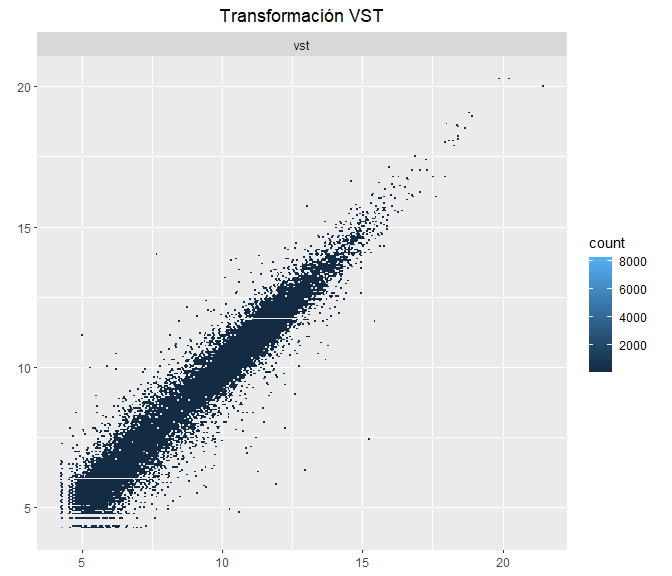

Transformación vst

En el *scatterplot* que se muestra arriba, se observa que los genes con conteos bajos (abajo a la izquierda) parecen ser excesivamente variables, sin mostrar diferencias para los genes con conteos bajos tal y como se experaba tras la transformación VST.

Sin embargo, en la teoría del curso hemos observado la comparación de la transformación VST con la transformación *rlog* y la tradicional *log2*. En este caso se había comentado que no se iba a utilizar la transformación *rlog* puesto que tenemos 30 muestras (30 es el punto de corte que establece la teoría para elegir VST o *rlog*) y computacionalmente es más rápido el método *VST*. Sin embargo, al observar el resultado en el gráfico anterior, he visto necesario comparar las tres gráficas (*vst, rlog* y *log2*) tal y como se hace en lo aprendido durante el curso. De este modo, podremos observar si la transformación VST es más explicativa a la hora de mostrar las diferencias entre los genes. El resultado se observa a continuación:

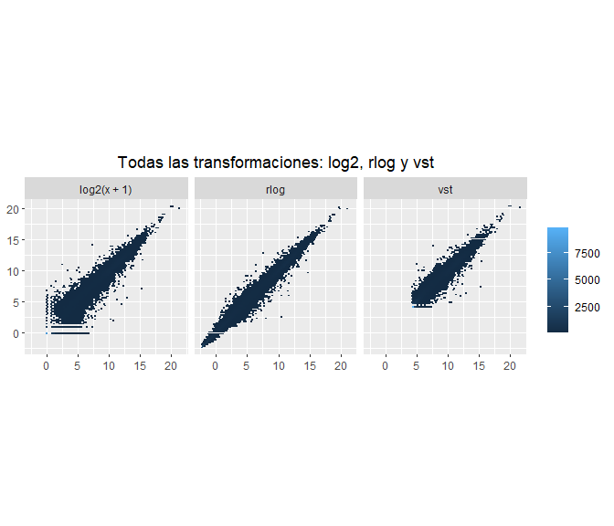

Las tres comparaciones: log2 (izquierda), vst (derecha) y rlog (centro)

En este segundo conjunto de gráficos que se muestra, se pueden observar la transformación *log2* de los datos normalizados (a la izquierda), la transformación *rlog* en la mitad y en la derecha otra vez la transformación VST. Sin embargo, al observar la transformación VST junto con las otras dos, la interpretación del gráfico es diferente al gráfico anterior (aunque en realidad muestren lo mismo). El gráfico VST muestra una tendencia hacia arriba (*upward shift*) de los valores más bajos. Se observa que en el caso de *log2*, los conteos bajos son excesivamente variables. En el caso del VST y del *rlog*, éstos comprimen las diferencias para los genes de conteo bajos, de los cuales el conjunto de datos da poca información sobre la expresión diferencial.

También es posible representar la transformación mediante gráficos de cajas (*boxplots*):

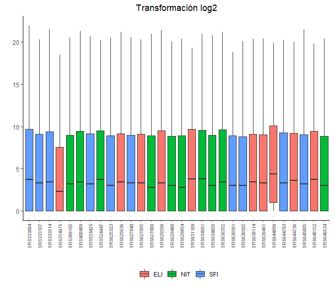

Boxplot para la transformación log2

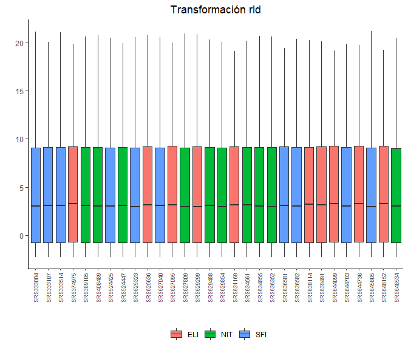

Boxplot para la transformación rld

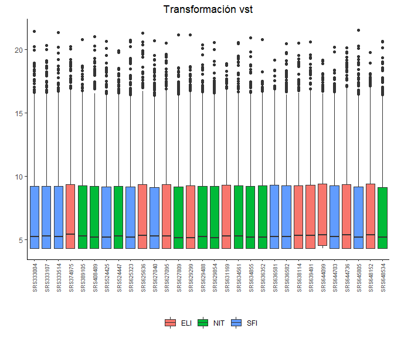

Boxplot para la transformación vsd

Los gráficos mediante *boxplot* de las distribuciones de conteo en cada muestra son una buena forma para entender el efecto que las transformaciones tienen a nivel individual de cada muestra. En los boxplots, son conocidos los circulos para mostrar puntos *outliers*. En los tres gráficos mostrados, ni el gráfico de la distribución *log2* ni la distribución *rlog* muestran valores *outlier* en la parte alta de la distribución. Sin embargo, la transformación *vst* si que tiene *outliers*, dado que este método comprime los valores más bajos de forma más considerable que los otros dos métodos, de la misma manera que se puede observar en los gráficos de puntos (*scatterplots*) mostrados anteriormente.

#### 3.2.2.3 Distancia entre muestras

Para el análisis secuencial RNA, es aconsejable que uno de los primeros pasos sea evaluar la similitud entre la distancia de las muestras para observar qué muestras son parecidas unas con otras. Para ello se utilizará la función *dist* para calcular la distancia euclidiana entre las muestras del estudio, y lo aplicaremos sobre los datos transformados mediante VST. Necesitaremos llevar a cabo la transpuesta de la matriz de valores utilizando la función *t*.

#### 3.2.2.4 Gráfico PCA

Otro modo de analizar las distancias entre las muestras es mediante el análisis PCA, en sus siglas en inglés *Principal Component Analysis*. En el eje *x* se muestra la distancia en la cual las muestras se separan entre ellas más, y los valores en esta dirección se definen como PC1. El eje *y* define otra dirección perpendicular a la del eje *x* donde los datos se separan más después de PC1, y se denomina PC2. El gráfico PCA utilizando los datos VST se muestra a continuación:

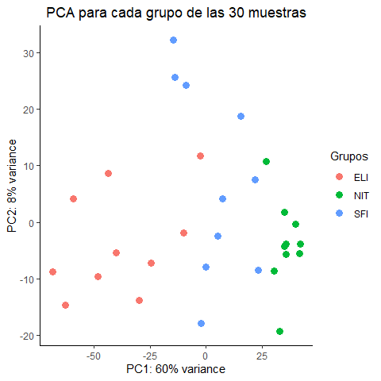

Gráfico PCA

Dado que en nuestro caso tenemos 10 muestras de cada group (ELI, NIT o SFI) y en total obtenemos 30 muestras independientes, se ha optado por aplicar la función *plotPCA* pero filtrando las muestras por el tipo de grupo al que pertenecen. De este modo, en lugar de obtener 30 puntos de distintos colores cada uno perteneciente a cada una de las muestras seleccionadas al principio, se muestran 10 puntos de cada color, cada uno de los tres grupos del análisis. Es importante tener en cuenta que el porcentaje total de PC1 y PC2 no suman 100%, dado que hay más dimensiones que tienen la varianza restante.

En este caso, no se ha llevado a cabo el gráfico MDS puesto que con el PCA hemos obtenido suficiente información a partir de los datos transformados mediante *vst*.

### 3.2.3 Identificación de genes diferencialmente expresados

Utilizando la función *DESeq*, sobre el objeto *ddsMat* (objeto *DESeqDataSet*), llevaremos a cabo el análisis de la expresión diferencial en los conteos brutos.

```
## class: DESeqDataSet
## dim: 43178 30
## metadata(1): version
## assays(6): counts mu ... replaceCounts replaceCooks
## rownames(43178): ENSG00000000003 ENSG00000000005 ... ENSG00000273492
##   ENSG00000273493
## rowData names(27): baseMean baseVar ... maxCooks replace
## colnames(30): SRS333004 SRS333107 ... SRS648152 SRS648534
## colData names(11): Experiment SRA_Sample ... sizeFactor replaceable
```

La función *DESeq* devuelve un objeto *DESeqDataSet* que contiene todos los parámetros ajustados.

En las siguientes sub-secciones, llevaremos a cabo la extracción de tablas de resultados de interés para el análisis de esta PEC. Empezaremos con la comparación 1: *SFI vs NIT*.

#### 3.2.3.1 Comparación 1: SFI vs NIT

La primera comparación que se llevará a cabo será la del Grupo **SFI vs NIT**. Para ello, mediante la función *results*, contrastaremos (con la función *contrast*) los niveles SFI y NIT de la variable Group.

Es importante destacar la *meta-data* que incorpora la comparación realizada:

```
## DataFrame with 6 rows and 2 columns
##                        type                               description
##                 <character>                               <character>
## baseMean       intermediate mean of normalized counts for all samples
## log2FoldChange      results  log2 fold change (MLE): Group SFI vs NIT
## lfcSE               results          standard error: Group SFI vs NIT
## stat                results          Wald statistic: Group SFI vs NIT
## pvalue              results       Wald test p-value: Group SFI vs NIT
## padj                results                      BH adjusted p-values
```

También, la información numérica de la comparación:

```
##
## out of 43178 with nonzero total read count
## adjusted p-value < 0.1
## LFC > 0 (up)       : 471, 1.1%
## LFC < 0 (down)     : 207, 0.48%
## outliers [1]       : 0, 0%
## low counts [2]     : 15905, 37%
## (mean count < 2)
## [1] see 'cooksCutoff' argument of ?results
## [2] see 'independentFiltering' argument of ?results
```

Una vez se han analizado los resultados de la comparación de los dos grupos, cabe destacar que hay dos maneras para determinar que genes se pueden considerar significantes:

- Reducir el umbral del *false discovery rate (FDR)*
- Aumentar el umbral del *log2* desde 0 utilizando el argumento *lfcThreshold* en la función *results*.

Utilizando el primer método, obtenemos (reduciendo el umbral del *false discovery rate (FDR)*) 23608 falsos positivos y 5339 true positives. Obtenemos estos mismos valores de genes significativos para las tres comparaciones.

##### 3.2.3.1.1 Testeado múltiple

En el caso del mapeado múltiple, podríamos analizar qué pasaría si pusieramos el umbral del valor de p en un valor bajo, como por ejemplo 0.05 (5%).

Por la propia definición del p-valor, esperaríamos tener hasta un 5% de genes cuyo p-valor fuera inferior a 0.05. Del total de 43178 genes, serían 2159 genes, pero hemos obtenido 3671. Con los resultados obtenidos, este listado por lo tanto, tendría, 2159 / 3671 = 58.81% de falsos positivos.

En la columna de *padj* del objeto *res* (en concreto res__SFI_NIT) definido previamente, tenemos el p-valor ajustado según el ajuste de Benjamini-Hochberg (BH). Con el *padj* queremos saber la fracción de falsos positivos entre los genes que tengan un p-valor igual o inferior al umbral establecido.

Por lo tanto, si consideramos un 5% de falsos positivos aceptable, podemos considerar que todos los genes con un p-valor ajustado menor al 5% (0.05) serán significativos.

Por ello, se suma para ver a cuántos genes le pasa, y con el umbral en un 5%, obtenemos 463 genes significativos, cuyo p-valor sea menor o igual que un 5%.

#### 3.2.3.2 Comparación 2: ELI vs NIT

La segunda comparación que se llevará a cabo será la del Grupo **ELI vs NIT**. Para ello, mediante la función *results*, contrastaremos (con la función *contrast*) los niveles ELI y NIT de la variable Group.

Es importante destacar la *meta-data* que incorpora la comparación realizada:

```
## DataFrame with 6 rows and 2 columns
##                        type                               description
##                 <character>                               <character>
## baseMean       intermediate mean of normalized counts for all samples
## log2FoldChange      results  log2 fold change (MLE): Group ELI vs NIT
## lfcSE               results          standard error: Group ELI vs NIT
## stat                results          Wald statistic: Group ELI vs NIT
## pvalue              results       Wald test p-value: Group ELI vs NIT
## padj                results                      BH adjusted p-values
```

También, la información numérica de la comparación:

```
##
## out of 43178 with nonzero total read count
## adjusted p-value < 0.1
## LFC > 0 (up)       : 4850, 11%
## LFC < 0 (down)     : 2817, 6.5%
## outliers [1]       : 0, 0%
## low counts [2]     : 11720, 27%
## (mean count < 1)
## [1] see 'cooksCutoff' argument of ?results
## [2] see 'independentFiltering' argument of ?results
```

##### 3.2.3.2.1 Testeado múltiple

En el caso del mapeado múltiple, podríamos analizar qué pasaría si pusieramos el umbral del valor de p en un valor bajo, como por ejemplo 0.05 (5%).

Por la propia definición del p-valor, esperaríamos tener hasta un 5% de genes cuyo p-valor fuera inferior a 0.05. Del total de 43178 genes, serían 2159 genes y en este caso obtenemos 9599. Este listado por lo tanto, tendría, 2159 / 9599 = 22.49% falsos positivos.

En la columna de *padj* del objeto *res* (en concreto res__ELI_NIT) definido previamente, tenemos el p-valor ajustado según el ajuste de Benjamini-Hochberg (BH). Con el *padj* queremos saber la fracción de falsos positivos entre los genes que tengan un p-valor igual o inferior al umbral establecido.

Por lo tanto, si consideramos un 5% de falsos positivos aceptable, podemos considerar que todos los genes con un p-valor ajustado menor al 5% (0.05) serán significativos.

Por ello, vamos a sumar a cuántos genes le pasa, y con el umbral en un 5%, obtenemos 5800 genes significativos, cuyo p-valor es menor o igual que un 5%.

#### 3.2.3.3 Comparación 3: ELI vs SFI

La tercera comparación que se llevará a cabo será la del Grupo **ELI vs SFI**. Para ello, mediante la función *results*, contrastaremos (con la función *contrast*) los niveles ELI y SFI de la variable *Group*.

Es importante destacar la *meta-data* que incorpora la comparación realizada:

```
## DataFrame with 6 rows and 2 columns
##                        type                               description
##                 <character>                               <character>
## baseMean       intermediate mean of normalized counts for all samples
## log2FoldChange      results  log2 fold change (MLE): Group ELI vs SFI
## lfcSE               results          standard error: Group ELI vs SFI
## stat                results          Wald statistic: Group ELI vs SFI
## pvalue              results       Wald test p-value: Group ELI vs SFI
## padj                results                      BH adjusted p-values
```

También, la información numérica de la comparación:

```
##
## out of 43178 with nonzero total read count
## adjusted p-value < 0.1
## LFC > 0 (up)       : 4330, 10%
## LFC < 0 (down)     : 2821, 6.5%
## outliers [1]       : 0, 0%
## low counts [2]     : 12557, 29%
## (mean count < 1)
## [1] see 'cooksCutoff' argument of ?results
## [2] see 'independentFiltering' argument of ?results
```

##### 3.2.3.3.1 Testeado múltiple

En el caso del mapeado múltiple, podríamos analizar qué pasaría si pusieramos el umbral del valor de p en un valor bajo, como por ejemplo 0.05 (5%).

Por la propia definición del p-valor, esperaríamos tener hasta un 5% de genes cuyo p-valor fuera inferior a 0.05. Del total de 43178 genes, serían 2159 genes y aquí obtenemos 9202. Este listado por lo tanto, tendría, 2159 / 9202 = 23.46% falsos positivos.

Por lo tanto, si consideramos un 5% de falsos positivos aceptable, podemos considerar que todos los genes con un p-valor ajustado menor al 5% (0.05) serán significativos.

Por ello, vamos a sumar a cuántos genes le pasa y con el umbral en un 5%, obtenemos 5304 genes significativos, cuyo p-valor es menor o igual que un 5%.

### 3.2.4 Gráficos de los resultados

A continuación se muestran los gráficos para los resultados observados en el apartado anterior. Los gráficos se muestran para cada comparación llevada a cabo en el análisis.

#### 3.2.4.1 Comparación 1: SFI vs NIT

Para la comparación 1, los gráficos que se llevan a cabo son los siguientes:

##### 3.2.4.1.1 Counts plot

Mediante la función *plotCounts* (del paquete *ggbeeswarm*) se extraen los argumentos del objeto del *DESeqDataSet* (valor del conteo, grupo al que pertenece y la muestra *SRA_Sample*). El gráfico se muestra a continuación:

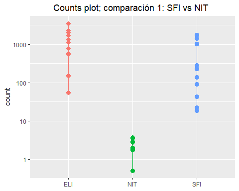

Count plot SFIvsNIT

Tal y como he hecho en el gráfico del PCA anteriormente, en este caso en lugar de mostrar de un color particular cada muestra *SRA* (SRA_Sample), éstas se han agrupado y mostrado dependiendo del grupo al que pertenecen, para facilitar la visualización de los datos.

##### 3.2.4.1.2 Histograma p-valores

Otro gráfico de diagnóstico que puede resultar interesante es el histograma de los p-valores. Este gráfico exluye a los genes con conteos muy bajos. El gráfico se muestra a continuación:

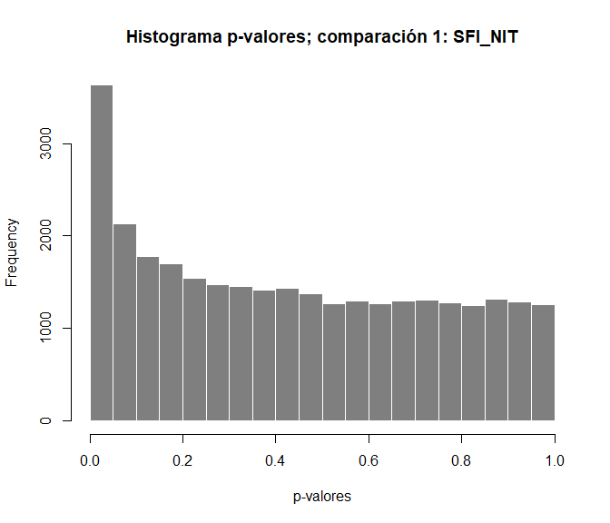

Histograma SFI vs NIT

#### 3.2.4.2 Comparación 2: ELI vs NIT

Para la comparación 2, los gráficos que se llevan a cabo son los mismos que para la comparación 1, utilizando los mismos pasos también. Por ello, únicamente se van a mostrar los resultados obtenidos.

##### 3.2.4.2.1 Counts plot

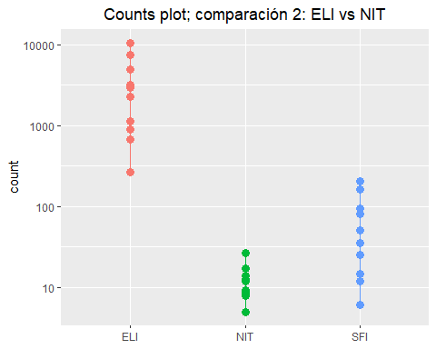

Count plot para comparación ELI vs NIT

##### 3.2.4.2.2 Histograma p-valores

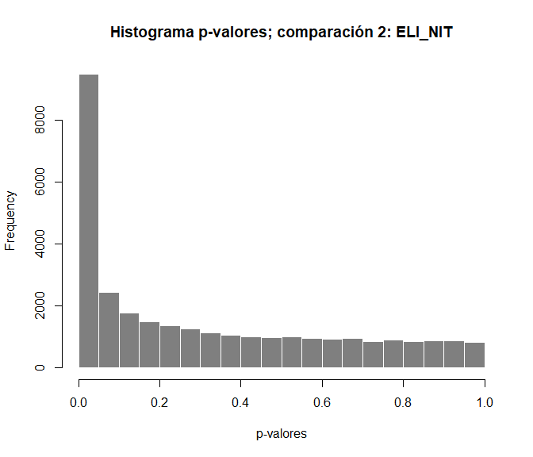

Histograma ELI vs NIT

#### 3.2.4.3 Comparación 3: ELI vs SFI

Para la comparación 3, los gráficos que se llevan a cabo son los siguientes, utilizando los mismos pasos que anteriormente, por lo tanto una vez más, únicamente se mostrarán los resultados obtenidos.

##### 3.2.4.3.1 Counts plot

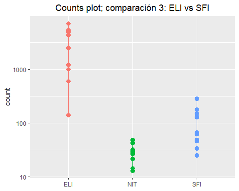

Count plot para comparación ELI vs SFI

##### 3.2.4.3.2 Histograma p-valores

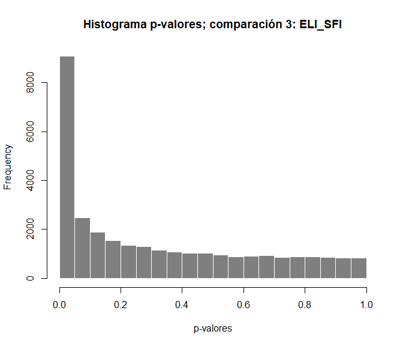

Histograma ELI vs SFI

**Conclusión de los gráficos llevados a cabo**

Tras observar los gráficos mostrados (desde la figura 8 hasta la 14, excluyendo la figura 10), la conclusión que se obtiene es la siguiente:

- En los gráficos *count* (figuras 8, 11 y 13), se observa que en las tres comparaciones el grupo ELI tiene un conteo mayor, y en la segunda comparación las 10 muestras que lo compone están más distanciadas entre ellas, mostrado mayor variación. El grupo NIT, en las tres comparaciones se muestra similar, en la parte baja, en el conteo más bajo. En el caso del grupo SFI, estas muestras están más separadas que las del grupo NIT, y en la primera y tercera combinación (cuando está presente en la comparación) los conteos son más altos que en la comparación 2 donde se compara ELI vs NIT.
- En los histogramas (figuras 9, 12 y 14), en los tres casos el conteo mayor se da cuando el p-valor es 0. En la primera comparación, la diferencia entre el p-valor cero y el siguiente p-valor no es tan alta como en las comparaciones 2 y 3, donde el p-valor diferente a cero es mucho más bajo en comparación. Relacionado con esto último, en la primera comparación para un p-valor cuyo valor es cero hay algo más de 3000 genes, pero en las demás comparaciones (2 y 3), el p-valor con valor cero se da en más de 8000 genes (por ello la diferencia tan alta con los otros p-valores cuyos conteos son más bajos).

### 3.2.5 Anotación de los resultados

Nuestra tabla de resultados contiene los ID de los genes Ensembl. Sin embargo, trabajar con nombres alternativos puede resultar más informativo para la interpretación final. Por ello, hemos cargado el organismo humano (*org.Hs.eg.db*) de la librería del mismo nombre.

Posteriormente, con la función *mapIds*, unimos a cada una de las comparaciones la columna *symbol* y *entrez* para que tengan el ID del gen externo.

#### 3.2.5.1 Comparación 1: SFI vs NIT

A continuación se muestra el *header* obtenido para la comparación 1:

```
## log2 fold change (MLE): Group SFI vs NIT
## Wald test p-value: Group SFI vs NIT
## DataFrame with 6 rows and 8 columns
##                         baseMean   log2FoldChange             lfcSE
##                        <numeric>        <numeric>         <numeric>
## ENSG00000211937 619.773418584042 8.35047382021992 0.761593224457381
## ENSG00000132465 7349.02923550539 5.35038430765302 0.528210744306637
## ENSG00000211941 495.663839232643 7.25731722208838 0.722905964889946
## ENSG00000170476 1410.65918707168 5.34129880315084 0.562881195148351
## ENSG00000244116 928.304112497323  6.5698519035362 0.696684711646244
## ENSG00000244575 357.202870500616 6.83787553312146 0.737517957186672
##                             stat               pvalue                 padj
##                        <numeric>            <numeric>            <numeric>
## ENSG00000211937 10.9644801871359 5.66250042367459e-28 1.54433374054877e-23
## ENSG00000132465 10.1292606508341 4.09735757185101e-24 5.58736165285463e-20
## ENSG00000211941 10.0390888643355 1.02617613241052e-23 9.32896721974407e-20
## ENSG00000170476 9.48921166524866 2.32788042641351e-21 1.58720707173939e-17
## ENSG00000244116 9.43016517186354 4.09443700640198e-21 2.23335160951202e-17
## ENSG00000244575 9.27146988963516 1.83598055428986e-20 8.34544960952454e-17
##                      symbol      entrez
##                 <character> <character>
## ENSG00000211937          NA          NA
## ENSG00000132465      JCHAIN        3512
## ENSG00000211941          NA          NA
## ENSG00000170476        MZB1       51237
## ENSG00000244116          NA          NA
## ENSG00000244575          NA          NA
```

#### 3.2.5.2 Comparación 2: ELI vs NIT

El proceso para la comparación 2 ha sido igual que para la comparación 1. El resultado obtenido es parecido, y se puede observar en el archivo csv que se ha generado.

#### 3.2.5.3 Comparación 3: ELI vs SFI

El proceso para la comparación 3 ha sido igual que para las comparaciones anteriores. El resultado obtenido es parecido, y se puede observar en el archivo csv que se ha generado.

#### 3.2.5.4 Exportando los resultados

Hemos guardado los resultados en un archivo `csv`, denominado *resultados_* junto con el nombre de la comparación correspondiente.

#### 3.2.5.5 Visualización de la expresión diferencial

Una manera de llevar a cabo la visualización de la expresión diferencial es mediante el uso de *volcano-plots*. Estos gráficos muestran la cantidad de genes con un gran *fold-change* y también si su expresión es significativa o no. En este caso, se ha llevado a cabo un gráfico por cada una de las comparaciones descritas durante toda la práctica. En el eje x, se muestra el cambio de expresión en escala logarítmica (el efecto biológico) y en el eje *y* el logaritmo (negativo) del valor de *p*. En este caso, en los tres Volcano-Plots se ha optado por representar el símbolo del gen (*symbol column of the DF*).

Para llevar a cabo los gráficos, se ha utilizado el paquete de reciente creación *EnhancedVolcano* (Blighe (2018)). Mediante la función con el mismo nombre, se han generado los tres gráficos tal y como se muestra a continuación, con un valor del *p cut-off* de 0.05.

##### 3.2.5.5.1 Comparación 1: SFI vs NIT

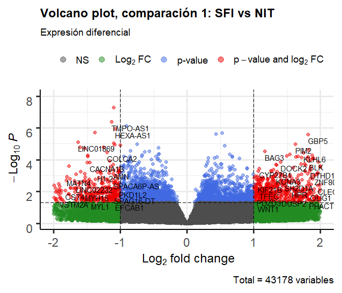

Volcano plot comparación 1, SFI vs NIT

##### 3.2.5.5.2 Comparación 2: ELI vs NIT

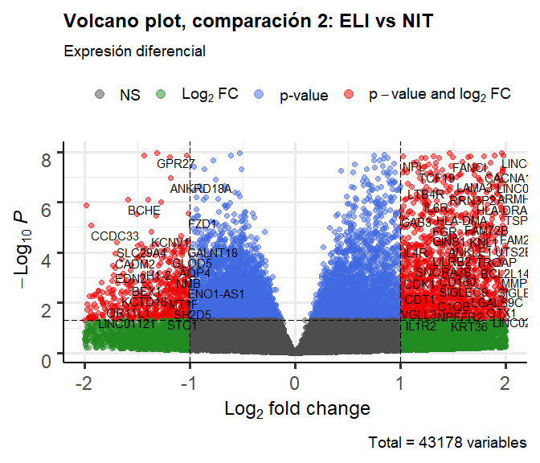

Volcano plot comparación 2, ELI vs NIT

##### 3.2.5.5.3 Comparación 3: ELI vs SFI

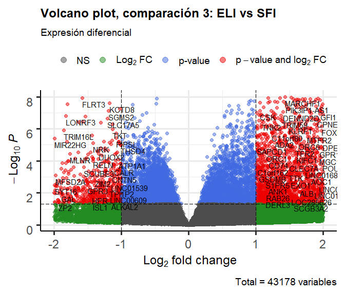

Volcano plot comparación 3, ELI vs SFI

### 3.2.6 Búsqueda de patrones de expresión y agrupación de las muestras

En este apartado se llevan a cabo las comparaciones entre los distintos grupos.

#### 3.2.6.1 Diagrama de Venn

Un método para la agrupación de las muestras es el uso del diagrama de Venn. Para llevarlo a cabo, se han cogido las columnas del p-valor de los *dataframes* generados anteriormente en las anotaciones de los resultados (en las tres comparaciones). Con estas tres columnas, hemos generado una matriz y con la función *decideTests* se han anotado y contado los genes seleccionados en las tres comparaciones mencionadas durante este análisis. Posteriormente, con los genes seleccionados, se ha llevado a cabo el diagrama de Venn.

Además, tal y como se puede observar a continuación, obtenemos un resumen de la cantidad de genes significativos y no significativos en cada unas de las comparaciones. Posteriormente, con esos datos se lleva a cabo el diagrama, tal y como se muestra en la siguiente imagen:

```
##        SFI_vs_NIT ELI_vs_NIT ELI_vs_SFI
## NotSig      42652      36460      37022
## Sig           526       6718       6156
```

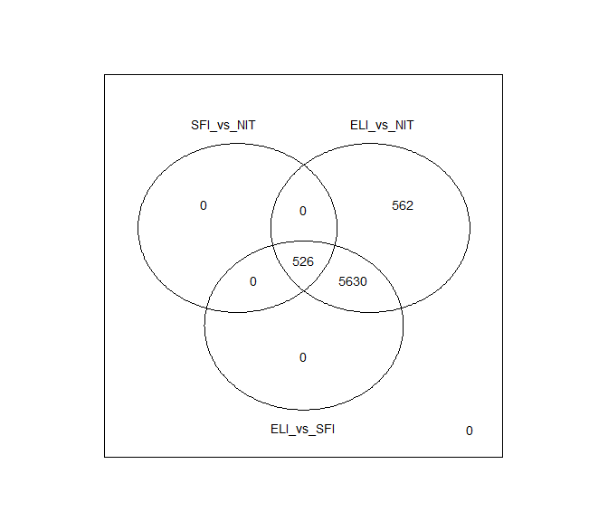

Diagrama de Venn que muestra los genes en común entre las tres comparaciones llevadas a cabo

Tal y como se observa en el resumen, la comparación SFI vs NIT tiene 526 genes significativos, pero todos ellos están en común con las otras dos comparaciones. La comparación ELI vs NIT, tiene 6718 genes significativos, de los cuales 526 son los mismos que comentábamos para el grupo 1, 5630 son en común con la comparación ELI vs SFI y los 562 restantes son únicamente significativos para esa comparación. En la última comparación, ELI vs SFI, están de nuevo los 526 genes en común entre los tres, y luego los 5630 genes en común con el grupo 2, ELI vs NIT, de sus 6156 genes significativos en total que tiene.

#### 3.2.6.2 Función degPatterns del paquete DEGreport

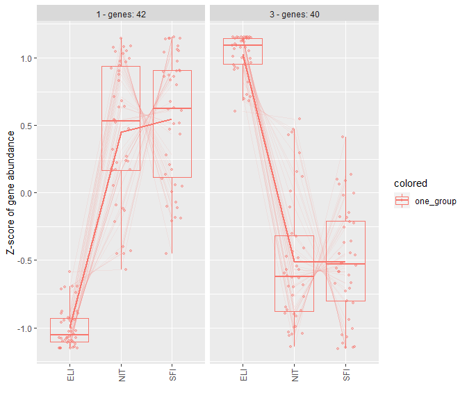

Boxplot comparativo de z-score para la abundancia entre las muestras de cada grupo según los genes

Es sabido que los valores de expresión de los genes normalmente se convierten a *Z-scores* con el objetivo de visualizarlos. El valor de *z* para una muestra indica el número de desviaciones estándar alejadas de la media de expresión en la referencia.

### 3.2.7 Análisis de significación biológica (“Gene Enrichment Analysis”)

Para llevar a cabo la significación biológica de los resultados, se utilizará el paquete *clusterProfiler*. El análisis de significación biológica se aplicará sobre las anotaciones llevadas a cabo anteriormente para cada comparación. Se utilizará la función *enrichGo* para el análisis de *enrichment* (significación). Los atributos introducidos a la función *enrichGo* son los siguientes: para *gene*, un vector de caracteres que hemos generado para la comparación, para *OrgDB*, nuestro organismo (org.Hs.eg.db), para *ont*, el proceso biológico de los genes diferenciados, el *pAdjustMethod*, BH- Benjamini-Hochberg y finalmente el *p-value cut-off* en 0.05.

Los datos obtenidos se han exportado a archivos *csv* en la carpeta de resultados, dentro del directorio de trabajo marcado al principio.

#### 3.2.7.1 Comparación 1: SFI vs NIT

Los resultados para la comparación 1, entre los grupos SFI y NIT, se muestran en la siguiente tabla:

First rows and columns for ClusterProfiler results on SFI vs NIT comparison

|  | Description | GeneRatio | BgRatio | pvalue | p.adjust |
| --- | --- | --- | --- | --- | --- |
| GO:0007409 | axonogenesis | 465/16804 | 468/18670 | 5.46015282475878e-18 | 3.53053481648903e-14 |
| GO:0044282 | small molecule catabolic process | 442/16804 | 445/18670 | 5.63038918212074e-17 | 1.82030482257964e-13 |
| GO:0015711 | organic anion transport | 476/16804 | 482/18670 | 1.88032796192829e-15 | 2.78795911906828e-12 |
| GO:0048732 | gland development | 430/16804 | 434/18670 | 2.1446827205058e-15 | 2.78795911906828e-12 |
| GO:0000280 | nuclear division | 404/16804 | 407/18670 | 2.594649313103e-15 | 2.78795911906828e-12 |

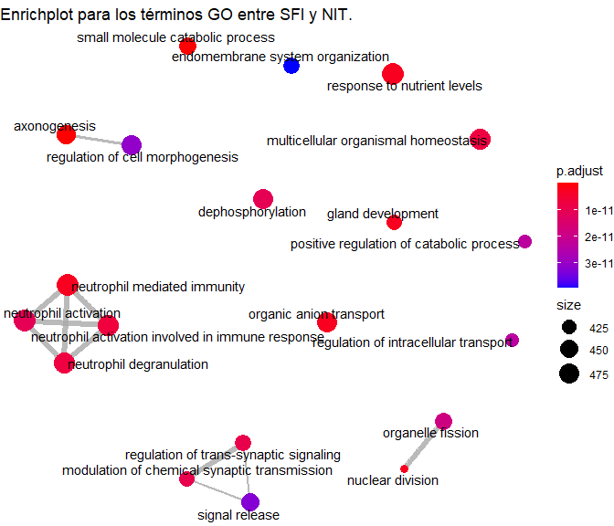

Análisis enrichment de los 20 términos GO más relevantes en la comparación

Otra posible forma de visualizar los resultados es mediante el gráfico *network* utilizando la función *cnetplot*. Esta función lo que hace es unir los genes con sus conceptos biológicos. Sin embargo, en este caso el cnetplot está sobre-cargado, por lo tanto no es posible visualizar con claridad los resultados. También es posible llevar a cabo un heatplot pero ocurre lo mismo, que apenas es posible distinguir los resultados debido al gran número de términos.

#### 3.2.7.2 Comparación 2: ELI vs NIT

Los resultados para la comparación 2, entre los grupos ELI y NIT, se muestran en la siguiente tabla:

First rows and columns for ClusterProfiler results on ELI vs NIT comparison

|  | Description | GeneRatio | BgRatio | pvalue | p.adjust |
| --- | --- | --- | --- | --- | --- |
| GO:0007409 | axonogenesis | 465/16804 | 468/18670 | 5.46015282475878e-18 | 3.53053481648903e-14 |
| GO:0044282 | small molecule catabolic process | 442/16804 | 445/18670 | 5.63038918212074e-17 | 1.82030482257964e-13 |
| GO:0015711 | organic anion transport | 476/16804 | 482/18670 | 1.88032796192829e-15 | 2.78795911906828e-12 |
| GO:0048732 | gland development | 430/16804 | 434/18670 | 2.1446827205058e-15 | 2.78795911906828e-12 |
| GO:0000280 | nuclear division | 404/16804 | 407/18670 | 2.594649313103e-15 | 2.78795911906828e-12 |

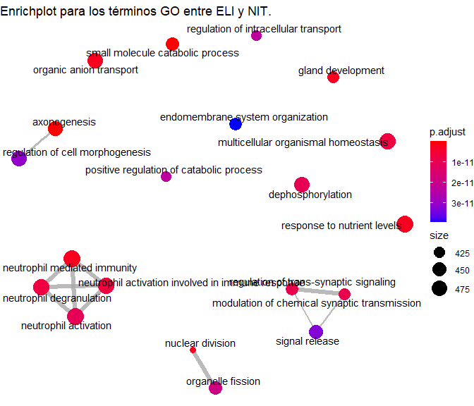

Análisis enrichment de los 20 términos GO más relevantes en la comparación

#### 3.2.7.3 Comparación 3: ELI vs SFI

Los resultados para la comparación 3, entre los grupos ELI y SFI, se muestran en la siguiente tabla:

First rows and columns for ClusterProfiler results on ELI vs SFI comparison

|  | Description | GeneRatio | BgRatio | pvalue | p.adjust |
| --- | --- | --- | --- | --- | --- |
| GO:0007409 | axonogenesis | 465/16804 | 468/18670 | 5.46015282475878e-18 | 3.53053481648903e-14 |
| GO:0044282 | small molecule catabolic process | 442/16804 | 445/18670 | 5.63038918212074e-17 | 1.82030482257964e-13 |
| GO:0015711 | organic anion transport | 476/16804 | 482/18670 | 1.88032796192829e-15 | 2.78795911906828e-12 |
| GO:0048732 | gland development | 430/16804 | 434/18670 | 2.1446827205058e-15 | 2.78795911906828e-12 |
| GO:0000280 | nuclear division | 404/16804 | 407/18670 | 2.594649313103e-15 | 2.78795911906828e-12 |

Los primeros 20 términos GO de la comparación con la función *emapplot* son los siguientes:

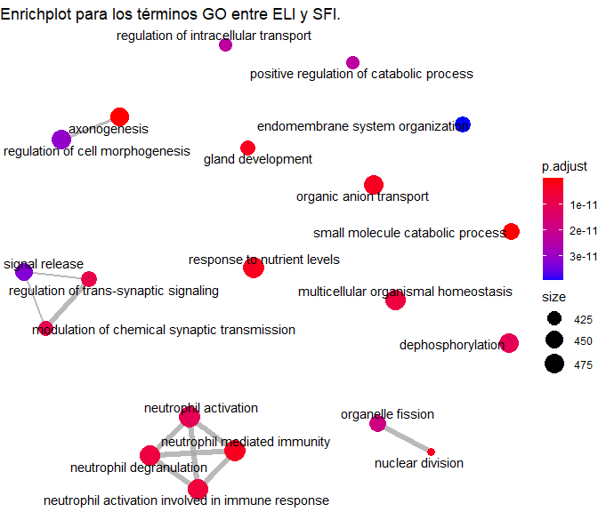

Análisis enrichment de los 20 términos GO más relevantes en la comparación

## 3.3 Archivos generados y software

Una vez que el proceso se lleva a cabo, es importante tener un listado de los archivos que se han generado en el análisis. Estos archivos resumen los resultados que se han obtenido y son de gran ayuda para la interpretación biológica. La siguiente tabla muestra el listados de los archivos generados en el estudio:

List of files generated in the analysis

| List_of_Files |
| --- |
| CusterProfiler.Results.ELI_NIT.csv |
| CusterProfiler.Results.ELI_SFI.csv |
| CusterProfiler.Results.SFI_NIT.csv |
| resultados_ELI_NIT.csv |
| resultados_ELI_SFI.csv |
| resultados_SFI_NIT.csv |
| seleccion_targets.csv |

Para la realización de este análisis tal y como es sabido se ha utilizado el software R. Para ello, ha sido necesario cargar varios paquetes nuevos al programa, muchos de ellos vinculados a Bioconductor. Algunos de esos ejemplos son los paquetes DESeq2, pheatmap, ggbeeswarm, genefilter, AnnotationDbi, EnhancedVolcano, DEGreport o clusterProfiler.

Como último paso en el *workflow* de este análisis, es posible utilizar la función *sessionInfo* que da la información de las versiones y los paquetes utilizados. De esta manera, se asegura la reproductividad del análisis con los mismos números y resultados obtenidos en caso de utilizar los mismos paquetes y versiones, y es más fácil observar qué paquete ha podido cambiar en un futuro.

[session information not shown]

# 4 Resultados

# 5 Discusión

Una limitación que puedo observar en el análisis llevado a cabo es el método de proceder en la comparación de los grupos en comparación con el estudio de microarrays realizado en la práctica anterior. En la pasada práctica, la comparación entre los diferentes niveles del factor que definía de qué clase eran las muestras me pareció más sencilla de llevar a cabo, puesto que se hacía en un único paso mediante la función *makeContrasts* para ver los efectos de cada tratamiento. En este caso, se ha tenido que repetir todo individualmente, lo que tampoco ha sido difícil pero indudablemente sí que ha sido más costoso. Finalmente, no encontrar diferencias entre las comparaciones llevadas a cabo, al menos en los primeros términos, resulta un tanto extraño, aunque quizá es debido a las muestras seleccionadas aleatoriamente con la semilla establecida en la primera parte del análisis o que tampoco hay tanta diferencia entre los tres grupos analizados. Habría que analizar más detalladamente el csv y ver dónde están las diferencias.

# 6 Apéndice

A continuación se muestra el script utilizado para la realización de esta práctica, aunque se aconseja su visualización en el archivo de R proporcionado en el repositorio de GitHub para poder analizarlo según va corriendo el programa.

```r
## Transforming the data to select the 30 samples:
targets<-read.csv("targets.csv",sep = ",")
counts<-read.csv("counts.csv",header = TRUE,sep = ";")
counts$X<-gsub("\\..*", "", counts$X, fixed = FALSE)

setwd(".")
dir.create("results")
dir.create("figures")

library(dplyr)
a<-split(targets,targets$Group)

gen<-function(df){
  set.seed(123)

  x<-as.data.frame(df[sample(nrow(df), 10),])

  return(x)

}

gen(targets)
l1<-lapply(a, gen)
fin<-bind_rows(l1)

library(tidyr)
levels(fin$Sample_Name) <- gsub("-", ".", levels(fin$Sample_Name)) # nos hemos dado cuenta que en counts tienen puntos y en targets -  entonces hemos sustituido todo.
counts.long<-counts %>%
  gather(Sample_Name,value,-X) %>%
  left_join(fin,by="Sample_Name") %>%
  filter(complete.cases(.))


library(tibble) # for the column_to_rownames function

counts.long2<-counts.long %>%
  dplyr::select(X,value,SRA_Sample)

counts.long3<-counts.long2 %>%
  spread(SRA_Sample,value) %>%
  column_to_rownames(var="X") %>%
  as.matrix()

fin<- fin %>%
  arrange(SRA_Sample)
write.csv(fin,file = "./results/seleccion_targets.csv")

all(as.vector(fin$SRA_Sample) == colnames(counts.long3))

# DESeq2 object
library(DESeq2)
ddsMat <- DESeqDataSetFromMatrix(countData = counts.long3,
                                 colData = fin,
                                 design = ~ Group)
ddsMat
### Preprocesado de los datos: filtraje y normalización

#### Pre-filtrado del conjunto de datos
ddsMat <- ddsMat[ rowSums(counts(ddsMat)) > 1, ]
nrow(ddsMat)
#### Transformación para estabilizar la varianza (vst)
vsd <- vst(ddsMat, blind = FALSE)
head(assay(vsd), 3)
colData(vsd)
library(ggplot2)

df <- bind_rows(
  as_data_frame(assay(vsd)[, 1:2]) %>% mutate(transformation = "vst"))

colnames(df)[1:2] <- c("x", "y")

ggplot(df, aes(x = x, y = y)) + geom_hex(bins = 250) +
  coord_fixed() + facet_grid( . ~ transformation)  +
  ggtitle("Transformación VST") +
  theme(plot.title = element_text(hjust = 0.5),
        axis.title.x = element_blank(),
        axis.title.y = element_blank())+
  ggsave("./figures/Figure1_transf_vst.tiff",last_plot(),"tiff",dpi=200)

rld <- rlog(ddsMat, blind = FALSE) # rlog transformation

ddsMat <- estimateSizeFactors(ddsMat) # for the log2 transformation

df <- bind_rows(
  as_data_frame(log2(counts(ddsMat, normalized=TRUE)[, 1:2]+1)) %>%
    mutate(transformation = "log2(x + 1)"),
  as_data_frame(assay(vsd)[, 1:2]) %>% mutate(transformation = "vst"),
  as_data_frame(assay(rld)[, 1:2]) %>% mutate(transformation = "rlog"))

colnames(df)[1:2] <- c("x", "y")

ggplot(df, aes(x = x, y = y)) + geom_hex(bins = 80) +
  coord_fixed() + facet_grid( . ~ transformation) +
  theme(axis.title.x = element_blank(),
        axis.title.y = element_blank(),
        legend.title = element_blank(),
        plot.title = element_text(hjust = 0.5)) +
  ggtitle("Todas las transformaciones: log2, rlog y vst") +
  ggsave("./figures/Figure2_all_transformations.tiff",last_plot(),"tiff",dpi=200)

a<-as.data.frame(log2(assay(ddsMat)+1)) %>%
  gather(SRA_Sample,value) %>%
  left_join(fin %>% select(SRA_Sample,Group),by="SRA_Sample")

ggplot(a,aes(x=SRA_Sample,y=value,fill=Group))+
  geom_boxplot()+
  theme_classic()+
  labs(x="",y="")+
  theme(legend.position = "bottom",
        legend.title = element_blank(),
        axis.text.x = element_text(size=7,angle = 90,vjust = .5),
        plot.title = element_text(hjust = 0.5))+
  ggtitle("Transformación log2")+
  ggsave("./figures/Figure3_transf_log2.tiff",last_plot(),"tiff",dpi=200)

b<-as.data.frame(assay(rld)) %>%
  gather(SRA_Sample,value) %>%
  left_join(fin %>% select(SRA_Sample,Group),by="SRA_Sample")

ggplot(b,aes(x=SRA_Sample,y=value,fill=Group))+
  geom_boxplot()+
  theme_classic()+
  labs(x="",y="")+
  theme(legend.position = "bottom",
        legend.title = element_blank(),
        axis.text.x = element_text(size=7,angle = 90,vjust = .5),
        plot.title = element_text(hjust = 0.5))+
  ggtitle("Transformación rld")+
  ggsave("./figures/Figure4_transf_rld.tiff",last_plot(),"tiff",dpi=200)

c<-as.data.frame(assay(vsd)) %>%
  gather(SRA_Sample,value) %>%
  left_join(fin %>% select(SRA_Sample,Group),by="SRA_Sample")

ggplot(c,aes(x=SRA_Sample,y=value,fill=Group))+
  geom_boxplot()+
  theme_classic()+
  labs(x="",y="")+
  theme(legend.position = "bottom",
        legend.title = element_blank(),
        axis.text.x = element_text(size=7,angle = 90,vjust = .5),
        plot.title = element_text(hjust = 0.5))+
  ggtitle("Transformación vst")+
  ggsave("./figures/Figure5_transf_vst.tiff",last_plot(),"tiff",dpi=200)

sampleDists <- dist(t(assay(vsd)))
library(pheatmap)
library(RColorBrewer)

sampleDistMatrix <- as.matrix( sampleDists )
rownames(sampleDistMatrix) <- paste( vsd$Group, vsd$SRA_Sample, sep = " - " ) ## Tenemos Group y Sra sample
colnames(sampleDistMatrix) <- NULL
colors <- colorRampPalette( rev(brewer.pal(9, "GnBu")) )(255)
pheatmap(sampleDistMatrix,
         clustering_distance_rows = sampleDists,
         clustering_distance_cols = sampleDists,
         col = colors,
         cellheight = 7.95,cellwidth = 7.95,
         main="Mapa de calor, distancias entre las 30 muestras", adj = 0, line = 0)
png(filename = "./figures/Figure6_pheatmap.png")
pheatmap(sampleDistMatrix,
         clustering_distance_rows = sampleDists,
         clustering_distance_cols = sampleDists,
         col = colors,
         cellheight = 7.95,cellwidth = 7.95,
         main="Mapa de calor, distancias entre las 30 muestras", adj = 0, line = 0)
#### Gráfico PCA
pcaData <-plotPCA(vsd, intgroup = c("Group", "SRA_Sample"),returnData = TRUE)
percentVar <- round(100 * attr(pcaData, "percentVar"))

ggplot(pcaData, aes(PC1, PC2, color=vsd$Group)) +
  geom_point(size=3) +
  theme_classic()+
  ggtitle("PCA para cada grupo de las 30 muestras") +
  theme(legend.position = "right",
        plot.title = element_text(hjust = 0.5)) +
  labs(color="Grupos") +
  xlab(paste0("PC1: ",percentVar[1],"% variance")) +
  ylab(paste0("PC2: ",percentVar[2],"% variance")) +
  coord_cartesian()+
  ggsave("./figures/Figure7_PCA.tiff",last_plot(),"tiff",dpi=200)
```

```r
dds <- DESeq(ddsMat, parallel =TRUE)
dds

#### SFI vs NIT
res_SFI_NIT <- results(dds, contrast=c("Group","SFI","NIT"))
mcols(res_SFI_NIT, use.names = TRUE)
summary(res_SFI_NIT)
res.05 <- results(dds, alpha = 0.05)
table(res.05$padj < 0.05)
##### Testeado múltiple
sum(res_SFI_NIT$pvalue < 0.05, na.rm=TRUE)
sum(res_SFI_NIT$padj < 0.05, na.rm=TRUE)
#### ELI vs NIT
res_ELI_NIT <- results(dds, contrast=c("Group","ELI","NIT"))
mcols(res_ELI_NIT, use.names = TRUE)
summary(res_ELI_NIT)
res.05 <- results(dds, alpha = 0.05)
table(res.05$padj < 0.05)
##### Testeado múltiple
sum(res_ELI_NIT$pvalue < 0.05, na.rm=TRUE)
sum(res_ELI_NIT$padj < 0.05, na.rm=TRUE)
#### ELI vs SFI
res_ELI_SFI <- results(dds, contrast=c("Group","ELI","SFI"))
mcols(res_ELI_SFI, use.names = TRUE)
summary(res_ELI_SFI)
res.05 <- results(dds, alpha = 0.05)
table(res.05$padj < 0.05)
##### Testeado múltiple
sum(res_ELI_SFI$pvalue < 0.05, na.rm=TRUE)
sum(res_ELI_SFI$padj < 0.05, na.rm=TRUE)

### Gráficos de los resultados
topGene <- rownames(res_SFI_NIT)[which.min(res_SFI_NIT$padj)]

library(ggbeeswarm)
geneCounts <- plotCounts(dds, gene = topGene, intgroup = c("Group","SRA_Sample"),
                         returnData = TRUE)
ggplot(geneCounts, aes(x = Group, y = count,color=Group)) +
  scale_y_log10() + geom_point(size = 3) + geom_line()+
  ggtitle("Counts plot; comparación 1: SFI vs NIT ") +
  theme(legend.position = "none",
        axis.title.x=element_blank(),
        plot.title = element_text(hjust = 0.5)) +
  ggsave("./figures/Figure8_count_plot_SFI_vs_NIT.tiff",last_plot(),"tiff",dpi=200)

hist(res_SFI_NIT$pvalue[res_SFI_NIT$baseMean > 1], breaks = 0:20/20,
     col = "grey50", border = "white",main = "Histograma p-valores; comparación 1: SFI_NIT",xlab = "p-valores" )

png(filename = "./figures/Figure9_hist_plot_SFI_vs_NIT.png")
hist(res_SFI_NIT$pvalue[res_SFI_NIT$baseMean > 1], breaks = 0:20/20,
     col = "grey50", border = "white",main = "Histograma p-valores; comparación 1: SFI_NIT",xlab = "p-valores" )

##### Agrupamiento genético (gene clustering)
library(genefilter)
topVarGenes <- head(order(rowVars(assay(vsd)), decreasing = TRUE), 10)

mat  <- assay(vsd)[topVarGenes, ]
mat  <- mat - rowMeans(mat)
anno <- as.data.frame(colData(vsd)[, c("SRA_Sample","Group")])

annotation_colors = list(  Group = c(SFI="blue", NIT="green",ELI="red"))

pheatmap(mat, annotation_col = anno, cellheight = 7.95,cellwidth = 7.95,col = colors,
         cex = 0.75,cluster_cols = TRUE,annotation_legend = TRUE,
         annotation_colors = annotation_colors,main = "Heatmap o mapa de calor con los datos VST")

png(filename = "./figures/Figure10_pheatmap_vst_trans_values.png")
pheatmap(mat, annotation_col = anno, cellheight = 7.95,cellwidth = 7.95,
         col = colors, cex = 0.75,cluster_cols = TRUE,annotation_legend = TRUE,
         annotation_colors = annotation_colors,main = "Heatmap o mapa de calor con los datos VST")

topGene <- rownames(res_ELI_NIT)[which.min(res_ELI_NIT$padj)]

library(ggbeeswarm)
geneCounts <- plotCounts(dds, gene = topGene, intgroup = c("Group","SRA_Sample"),
                         returnData = TRUE)


ggplot(geneCounts, aes(x = Group, y = count,color=Group)) +
  scale_y_log10() + geom_point(size = 3) + geom_line()+
  ggtitle("Counts plot; comparación 2: ELI vs NIT") +
  theme(legend.position = "none",
        axis.title.x=element_blank(),
        plot.title = element_text(hjust = 0.5)) +
  ggsave("./figures/Figure11_count_plot_ELI_vs_NIT.tiff",last_plot(),"tiff",dpi=200)

hist(res_ELI_NIT$pvalue[res_ELI_NIT$baseMean > 1], breaks = 0:20/20,
     col = "grey50", border = "white",main = "Histograma p-valores; comparación 2: ELI_NIT",xlab = "p-valores" )

png(filename = "./figures/Figure12_hist_plot_ELI_vs_NIT.png")
hist(res_ELI_NIT$pvalue[res_ELI_NIT$baseMean > 1], breaks = 0:20/20,
     col = "grey50", border = "white",main = "Histograma p-valores; comparación 2: ELI_NIT",xlab = "p-valores" )

topGene <- rownames(res_ELI_SFI)[which.min(res_ELI_SFI$padj)]

library(ggbeeswarm)
geneCounts <- plotCounts(dds, gene = topGene, intgroup = c("Group","SRA_Sample"),
                         returnData = TRUE)

ggplot(geneCounts, aes(x = Group, y = count,color=Group)) +
  scale_y_log10() + geom_point(size = 3) + geom_line()+
  ggtitle("Counts plot; comparación 3: ELI vs SFI") +
  theme(legend.position = "none",
        axis.title.x=element_blank(),
        plot.title = element_text(hjust = 0.5)) +
  ggsave("./figures/Figure13_count_plot_ELI_vs_SFI",last_plot(),"tiff",dpi=200)

hist(res_ELI_SFI$pvalue[res_ELI_SFI$baseMean > 1], breaks = 0:20/20,
     col = "grey50", border = "white",main = "Histograma p-valores; comparación 3: ELI_SFI",xlab = "p-valores" )

png(filename = "./figures/Figure14_hist_plot_ELI_vs_SFI.png")
hist(res_ELI_SFI$pvalue[res_ELI_SFI$baseMean > 1], breaks = 0:20/20,
     col = "grey50", border = "white",main = "Histograma p-valores; comparación 3: ELI_SFI",xlab = "p-valores" )

### Anotación de los resultados
library(AnnotationDbi)
library(org.Hs.eg.db)

res_SFI_NIT$symbol <- mapIds(org.Hs.eg.db,
                             keys=row.names(res_SFI_NIT),
                             column="SYMBOL",
                             keytype="ENSEMBL",
                             multiVals="first")
res_SFI_NIT$entrez <- mapIds(org.Hs.eg.db,
                             keys=row.names(res_SFI_NIT),
                             column="ENTREZID",
                             keytype="ENSEMBL",
                             multiVals="first")

resOrdered_SFI_NIT <- res_SFI_NIT[order(res_SFI_NIT$pvalue),]
head(resOrdered_SFI_NIT)

res_ELI_NIT$symbol <- mapIds(org.Hs.eg.db,
                             keys=row.names(res_ELI_NIT),
                             column="SYMBOL",
                             keytype="ENSEMBL",
                             multiVals="first")
res_ELI_NIT$entrez <- mapIds(org.Hs.eg.db,
                             keys=row.names(res_ELI_NIT),
                             column="ENTREZID",
                             keytype="ENSEMBL",
                             multiVals="first")
```

```r
resOrdered_ELI_NIT <- res_ELI_NIT[order(res_ELI_NIT$pvalue),]

res_ELI_SFI$symbol <- mapIds(org.Hs.eg.db,
                             keys=row.names(res_ELI_SFI),
                             column="SYMBOL",
                             keytype="ENSEMBL",
                             multiVals="first")
res_ELI_SFI$entrez <- mapIds(org.Hs.eg.db,
                             keys=row.names(res_ELI_SFI),
                             column="ENTREZID",
                             keytype="ENSEMBL",
                             multiVals="first")

resOrdered_ELI_SFI <- res_ELI_SFI[order(res_ELI_SFI$pvalue),]

#### Exportando los resultados
resOrderedDF_SFI_NIT <- as.data.frame(resOrdered_SFI_NIT)
resOrderedDF_ELI_NIT <- as.data.frame(resOrdered_ELI_NIT)
resOrderedDF_ELI_SFI <- as.data.frame(resOrdered_ELI_SFI)
write.csv(resOrderedDF_SFI_NIT, file = "./results/resultados_SFI_NIT.csv")
write.csv(resOrderedDF_ELI_NIT, file = "./results/resultados_ELI_NIT.csv")
write.csv(resOrderedDF_ELI_SFI, file = "./results/resultados_ELI_SFI.csv")

library(EnhancedVolcano)
EnhancedVolcano(resOrderedDF_SFI_NIT,
                lab = resOrderedDF_SFI_NIT$symbol,
                x = 'log2FoldChange',
                y = 'pvalue',
                xlim = c(-2, 2),
                ylim = c(0, 8),
                title = "Volcano plot, comparación 1: SFI vs NIT",
                subtitle = "Expresión diferencial",
                labSize = 4.0,
                pCutoff = 0.05)

png(filename = "./figures/Figure15_Volcano_plot_SFI_vs_NII.png")
EnhancedVolcano(resOrderedDF_SFI_NIT,
                lab = resOrderedDF_SFI_NIT$symbol,
                x = 'log2FoldChange',
                y = 'pvalue',
                xlim = c(-2, 2),
                ylim = c(0, 8),
                title = "Volcano plot, comparación 1: SFI vs NIT",
                subtitle = "Expresión diferencial",
                labSize = 4.0,
                pCutoff = 0.05)

EnhancedVolcano(resOrderedDF_ELI_NIT,
                lab = resOrderedDF_ELI_NIT$symbol,
                x = 'log2FoldChange',
                y = 'pvalue',
                xlim = c(-2, 2),
                ylim = c(0, 8),
                title = "Volcano plot, comparación 2: ELI vs NIT",
                subtitle = "Expresión diferencial",
                labSize = 4.0,
                pCutoff = 0.05)
png(filename = "./figures/Figure16_Volcano_plot_ELI vs NIT.png")
EnhancedVolcano(resOrderedDF_ELI_NIT,
                lab = resOrderedDF_ELI_NIT$symbol,
                x = 'log2FoldChange',
                y = 'pvalue',
                xlim = c(-2, 2),
                ylim = c(0, 8),
                title = "Volcano plot, comparación 2: ELI vs NIT",
                subtitle = "Expresión diferencial",
                labSize = 4.0,
                pCutoff = 0.05)

EnhancedVolcano(resOrderedDF_ELI_SFI,
                lab = resOrderedDF_ELI_SFI$symbol,
                x = 'log2FoldChange',
                y = 'pvalue',
                xlim = c(-2, 2),
                ylim = c(0, 8),
                title = "Volcano plot, comparación 3: ELI vs SFI",
                subtitle = "Expresión diferencial",
                labSize = 4.0,
                pCutoff = 0.05)

png(filename = "./figures/Figure17_Volcano_plot_ELI vs SFI.png")
EnhancedVolcano(resOrderedDF_ELI_SFI,
                lab = resOrderedDF_ELI_SFI$symbol,
                x = 'log2FoldChange',
                y = 'pvalue',
                xlim = c(-2, 2),
                ylim = c(0, 8),
                title = "Volcano plot, comparación 3: ELI vs SFI",
                subtitle = "Expresión diferencial",
                labSize = 4.0,
                pCutoff = 0.05)

#### Diagrama de Venn
library(limma)
a<-as.matrix(resOrdered_SFI_NIT$pvalue)
b<-as.matrix(resOrdered_ELI_NIT$pvalue)
c<-as.matrix(resOrdered_ELI_SFI$pvalue)

decide_all<-cbind(a,b,c)
colnames(decide_all)<-c("SFI_vs_NIT","ELI_vs_NIT","ELI_vs_SFI")

res<-decideTests(decide_all, method="separate", adjust.method="fdr", p.value=0.1, lfc=1)
sum.res.rows<-apply(abs(res),1,sum)
res.selected<-res[sum.res.rows!=0,]
print(summary(res))

vennDiagram(res.selected[,1:3], cex=0.9)

png(filename = "./figures/Figure18_vennDiagram.png")
vennDiagram(res.selected[,1:3], cex=0.9)

#### Función degPatterns del paquete DEGreport
library(DEGreport)
ma_SFI_NIT = assay(vst(dds))[row.names(res_SFI_NIT)[1:100],]
pattern_SFI_NIT <- degPatterns(ma_SFI_NIT, metadata=  colData(dds), time = "Group")

png(filename = "./figures/Figure19_pattern.png")
ma_SFI_NIT = assay(vst(dds))[row.names(res_SFI_NIT)[1:100],]
pattern_SFI_NIT <- degPatterns(ma_SFI_NIT, metadata=  colData(dds), time = "Group")

### Análisis de significación biológica ("Gene Enrichment Analysis")
library(clusterProfiler)

#### Comparación 1: SFI vs NIT

OrgDb <- org.Hs.eg.db

geneList_SFI_NIT <- as.vector(resOrderedDF_SFI_NIT$log2FoldChange)
names(geneList_SFI_NIT) <- resOrderedDF_SFI_NIT$entrez
gene_SFI_NIT <- na.omit(resOrderedDF_SFI_NIT$entrez)

# Enrichment analysis
ego_SFI_NIT <- clusterProfiler::enrichGO(gene          = gene_SFI_NIT,
                                         OrgDb         = OrgDb,
                                         ont           = "BP",
                                         pAdjustMethod = "BH",
                                         pvalueCutoff  = 0.05,
                                         qvalueCutoff  = 0.05,
                                         readable      = TRUE)
#head(summary(ego_SFI_NIT)[,-8])

# guardando el resultado enrichment en el directorio como un csv
write.csv(as.data.frame(ego_SFI_NIT),
          file =paste0("./results/","CusterProfiler.Results.SFI_NIT.csv"),
          row.names = FALSE)

Tab.react1 <- read.csv2(file.path("./results/CusterProfiler.Results.SFI_NIT.csv"),
                        sep = ",", header = TRUE, row.names = 1)

Tab.react1 <- Tab.react1[1:5, 1:5]
knitr::kable(Tab.react1, booktabs = TRUE,
             caption = "First rows and columns for ClusterProfiler results on SFI vs NIT comparison")
```

```r
barplot_SFI_NIT<-barplot(ego_SFI_NIT, showCategory=25)
barplot_SFI_NIT

png(filename = "./figures/Figure20_boxplot_comp1.png")
barplot_SFI_NIT<-barplot(ego_SFI_NIT, showCategory=25)
barplot_SFI_NIT

emapplot(ego_SFI_NIT,pie="count", pie_scale=1.5, layout="nicely",
         color = "p.adjust",showCategory = 20) + ggtitle("Enrichplot para los términos GO entre SFI y NIT.")

png(filename = "./figures/Figure21_emapplot_comp1.png")
emapplot(ego_SFI_NIT,pie="count", pie_scale=1.5,
         layout="nicely",color = "p.adjust",showCategory = 20) +
  ggtitle("Enrichplot para los términos GO entre SFI y NIT.")

#### Comparación 2: ELI vs NIT
OrgDb <- org.Hs.eg.db

geneList_ELI_NIT <- as.vector(resOrderedDF_ELI_NIT$log2FoldChange)
names(geneList_ELI_NIT) <- resOrderedDF_ELI_NIT$entrez
gene_ELI_NIT <- na.omit(resOrderedDF_ELI_NIT$entrez)

# Enrichment analysis
ego_ELI_NIT <- clusterProfiler::enrichGO(gene          = gene_ELI_NIT,
                                         OrgDb         = OrgDb,
                                         ont           = "BP",
                                         pAdjustMethod = "BH",
                                         pvalueCutoff  = 0.05,
                                         qvalueCutoff  = 0.05,
                                         readable      = TRUE)
#head(summary(ego_ELI_NIT)[,-8])

# guardando el resultado enrichment en el directorio como un csv
write.csv(as.data.frame(ego_ELI_NIT),
          file =paste0("./results/","CusterProfiler.Results.ELI_NIT.csv"),
          row.names = FALSE)

Tab.react2 <- read.csv2(file.path("./results/CusterProfiler.Results.ELI_NIT.csv"),
                        sep = ",", header = TRUE, row.names = 1)

Tab.react2 <- Tab.react2[1:5, 1:5]
knitr::kable(Tab.react2, booktabs = TRUE,
             caption = "First rows and columns for ClusterProfiler results on ELI vs NIT comparison")

barplot_ELI_NIT<-barplot(ego_ELI_NIT, showCategory=25)
barplot_ELI_NIT

png(filename = "./figures/Figure22_boxplot_comp2.png")
barplot_ELI_NIT<-barplot(ego_ELI_NIT, showCategory=25)
barplot_ELI_NIT

emapplot(ego_ELI_NIT,pie="count", pie_scale=1.5, layout="nicely",
         color = "p.adjust",showCategory = 20) + ggtitle("Enrichplot para los términos GO entre ELI y NIT.")

png(filename = "./figures/Figure23_emapplot_comp2.png")
emapplot(ego_ELI_NIT,pie="count", pie_scale=1.5, layout="nicely",
         color = "p.adjust",showCategory = 20) + ggtitle("Enrichplot para los términos GO entre ELI y NIT.")

#### Comparación 3: ELI vs SFI
OrgDb <- org.Hs.eg.db

geneList_ELI_SFI <- as.vector(resOrderedDF_ELI_SFI$log2FoldChange)
names(geneList_ELI_SFI) <- resOrderedDF_ELI_SFI$entrez
gene_ELI_SFI <- na.omit(resOrderedDF_ELI_SFI$entrez)

# Enrichment analysis
ego_ELI_SFI <- clusterProfiler::enrichGO(gene          = gene_ELI_SFI,
                                         OrgDb         = OrgDb,
                                         ont           = "BP",
                                         pAdjustMethod = "BH",
                                         pvalueCutoff  = 0.05,
                                         qvalueCutoff  = 0.05,
                                         readable      = TRUE)
#head(summary(ego_ELI_SFI)[,-8])

# guardando el resultado enrichment en el directorio como un csv
write.csv(as.data.frame(ego_ELI_SFI),
          file =paste0("./results/","CusterProfiler.Results.ELI_SFI.csv"),
          row.names = FALSE)

Tab.react3 <- read.csv2(file.path("./results/CusterProfiler.Results.ELI_SFI.csv"),
                        sep = ",", header = TRUE, row.names = 1)

Tab.react3 <- Tab.react3[1:5, 1:5]
knitr::kable(Tab.react3, booktabs = TRUE,
             caption = "First rows and columns for ClusterProfiler results on ELI vs SFI comparison")

barplot_ELI_SFI<-barplot(ego_ELI_SFI, showCategory=25)
barplot_ELI_SFI
png(filename = "./figures/Figure24_boxplot_comp3.png")
barplot_ELI_SFI<-barplot(ego_ELI_SFI, showCategory=25)
barplot_ELI_SFI
emapplot(ego_ELI_SFI,pie="count", pie_scale=1.5, layout="nicely",
         color = "p.adjust",showCategory = 20) + ggtitle("Enrichplot para los términos GO entre ELI y SFI.")

png(filename = "./figures/Figure25_emapplot_comp3.png")
emapplot(ego_ELI_SFI,pie="count", pie_scale=1.5, layout="nicely",color = "p.adjust",showCategory = 20) +
  ggtitle("Enrichplot para los términos GO entre ELI y SFI.")
```

# References

Blighe, K. 2018. “Enhancedvolcano: Publication-Ready Volcano Plots with Enhanced Colouring and Labeling.”